# Figures - Network-based analysis of genome-wide biobank data boosts discovery of genetic associations in psoriasis

Abstract

Psoriasis is a common autoimmune disease with a strong genetic component. Targeting the *IL-23/IL-17* pathways for the treatment of moderate-severe psoriasis has proven successful, which makes it a good benchmark for other drug discovery approaches. Genome Wide Association Studies (GWAS) identify genetic loci associated with a phenotype (e.g. disease). However, using identified loci to understand the disease mechanisms remains challenging. In response, gene networks methods that consider gene-gene relationships have been developed. In a previous study, we showed that the combination of network methods improved the power, reproducibility, and interpretability of those approaches on a small cohort of breast cancer patients. The goal of the present study is to benchmark the performance of the same combination of network methods on a psoriasis cohort from the UK biobank (with a particular interest on the *IL-23/IL-17* pathways). By applying this method, we identified well known psoriasis genes, demonstrating the viability of our approach. Our method further identified a small set of genes of the MRPL family robustly associated with psoriasis, demonstrating that this approach can provide insights into the potential disease mechanisms. Our study also shows that our method is applicable to large-scale biobank data to produce novel findings, even in well-studied diseases with strong genetic signal.

## Contents

1. UpSet plot of gene sets across methods — Genes shared across the intersections of the sets selected by Heinz, MAGMABH, HotNet2, SigMod, dmGWAS, LEAN and cGWAS.
2. Consensus network (128 genes) — methods and gene source — Genes selected by ≥ 3 of 5 methods; pie charts show which methods picked each gene, label colours show whether it is also significant in cGWAS and/or MAGMABH.
3. Consensus network (128 genes) — known psoriasis gene lists — Same network, highlighting genes shared with the lists of Ran et al. (2019), Tsoi et al. (2017), Dand et al. (2025) and Zhang et al. (2025).
4. Consensus network (128 genes) — signalling pathways — Same network, highlighting genes in IL-17, IL-23, TNF, IL-1, IFN-γ, IL-22, IL-6, NF-κB, JAK-STAT, MAPK, PI3K-AKT and WNT pathways.

## UpSet plot of gene sets across methods

Genes shared across the intersections of the sets selected by Heinz, MAGMABH, HotNet2, SigMod, dmGWAS, LEAN and cGWAS.

↑ Back to contents

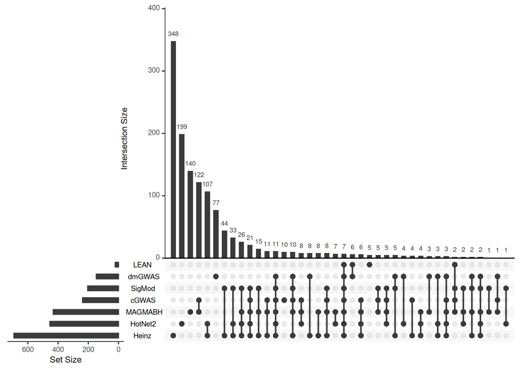

UpSet plot for representing all the common genes across different intersections of gene sets produced by the network-based methods. MAGAMBH corresponds to gene p-values outputted by MAGMA after applying the Benjamini-Hochberg procedure, cGWAS corresponds to gene p-values mapped from SNP p-values after the association test computed using PLINK v1.9.

```r
library(UpSetR)
library(tidyverse)
data_upset <- read_tsv("data/selected_genes_heinz-bhcorrection-hotnet2-sigmod-dmgwas-lean-cgwas.txt")
listInput <- as.list(data_upset)
names(listInput) <- c("Heinz","MAGMABH", "HotNet2", "SigMod", "dmGWAS", "LEAN", "cGWAS")

UpSetR::upset(fromList(listInput), nsets = 7, order.by = "freq", text.scale = c(1,1,1,1,1,1), set_size.show = FALSE, set_size.scale_max = 700)
```

## Consensus network (128 genes) — methods and gene source

Genes selected by ≥ 3 of 5 methods; pie charts show which methods picked each gene, label colours show whether it is also significant in cGWAS and/or MAGMABH.

↑ Back to contents

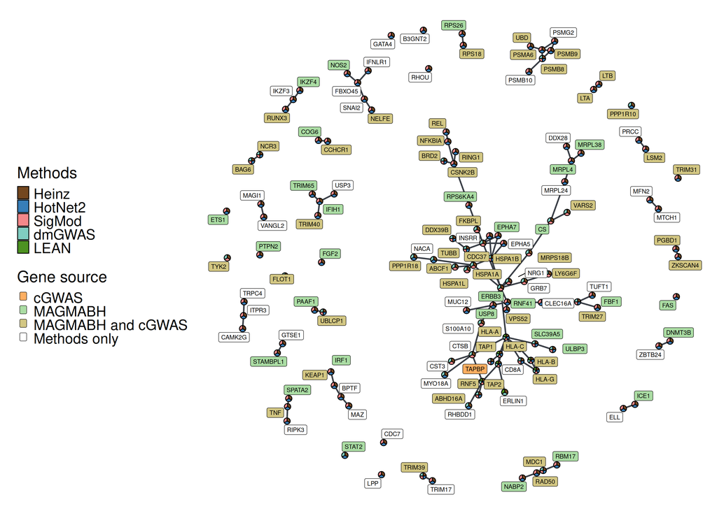

Consensus network built by choosing those genes that were selected in at least 3 of the 5 methods. The network contains 128 nodes corresponding to genes. Methods and genes are highlighted to depict which method (Methods, pie chart) selected one particular gene, and if a gene (Gene source, colored labels) was also found significant in classical GWAS (cGWAS), or by MAGMA analysis after Benjamini-Hochberg correction (MAGMABH).

```r
library(igraph)
library(tidygraph)
library(magrittr)
library(ggrepel)
library(tidyverse)
library(cowplot)
suppressMessages(library(network))
suppressMessages(library(sna))
library(ggnetwork)
library(scatterpie)
library(ggnewscale)

# Transparent ggplot theme (no panel, plot or legend background, no grid lines), so the figures can be placed on any background.
theme_transparent <- theme(panel.background = element_rect(fill = "transparent"), # bg of the panel
                           plot.background = element_rect(fill = "transparent", color = NA), # bg of the plot
                           panel.grid.major = element_blank(), # get rid of major grid
                           panel.grid.minor = element_blank(), # get rid of minor grid
                           legend.background = element_rect(fill = "transparent", color = NA), # get rid of legend bg
                           legend.box.background = element_rect(fill = "transparent", color = NA) # get rid of legend panel bg
)

theme_set(theme_cowplot() + theme_transparent)

ppi <- read_tsv('data/biogrid_mv_physical_4.4.249_tab2_onlyhuman_9606_interactorsAB.tsv', col_types = 'cc') %>%
  select(`Official Symbol Interactor A`, `Official Symbol Interactor B`) %>%
  graph_from_data_frame(directed = FALSE) %>%
  as_tbl_graph

methods <- c('Heinz','HotNet2', 'SigMod', 'cGWAS', 'MAGMABH', 'dmGWAS', 'LEAN', 'MAGMABHcGWAS')

method_palette <- c('Heinz' = '#73471f',
                    'HotNet2' = '#377eb8', 'SigMod' = '#f4888a', 'All' = 'gray50',
                    'Consensus' = 'black', 'MAGMABH' = '#abdda4', 'cGWAS' = '#fdae61', 'dmGWAS' = '#80cdc1', 'LEAN' = '#4d9221')

genesrc_palette <- c('MAGMABH' = '#abdda4', 'cGWAS' = '#fdae61', 'MAGMABH and cGWAS' = '#d3c783', 'Methods only' = '#ffffff')

plot_network <- function(net, selected_nodes) {

  graph <- activate(net, nodes) %>%
    filter(name %in% selected_nodes)
  class(graph) <- c('igraph','tbl_graph')

  ggnetwork(graph) %>%
    ggplot(aes(x = x, y = y, xend = xend, yend = yend)) +
    geom_edges(color = '#3282b8') +
    geom_nodes(color = '#233142', size = 4) +
    #geom_label(aes(label = name),
    #                 size = 2) +
    ggtitle(' ') +
    theme_blank() + theme_transparent +
    theme(title = element_text(hjust = 1, face = 'bold'))
}

# heinz
heinz <- read_tsv('data/heinz/selected_genes_split_1.heinz.txt', col_types = 'c')$gene
heinz_plt <- plot_network(ppi, heinz)
heinz_plt_square <- heinz_plt + coord_fixed(ratio = 1) # Add coord_fixed(ratio = 1) to make the plot square

# hotnet2
hotnet2 <- read_tsv('data/hotnet2/selected_genes_split_1.hotnet2.tsv', col_types = 'cc')$gene
hotnet2_plt <- plot_network(ppi, hotnet2)
hotnet2_plt_square <- hotnet2_plt + coord_fixed(ratio = 1)

# sigmod
sigmod <- read_tsv('data/sigmod/selected_genes_split_1.sigmod.txt', col_types = 'c')$gene
sigmod_plt <- plot_network(ppi, sigmod)
sigmod_plt_square <- sigmod_plt + coord_fixed(ratio = 1)

# dmgwas
dmgwas <- read_tsv('data/dmgwas/selected_genes_split_1.dmgwas.txt', col_types = 'c')$gene
dmgwas_plt <- plot_network(ppi, dmgwas)
dmgwas_plt_square <- dmgwas_plt + coord_fixed(ratio = 1)

# lean
lean <- read_tsv('data/lean/selected_genes_split_1.lean.txt', col_types = 'c')$gene
lean_plt <- plot_network(ppi, lean)
lean_plt_square <- lean_plt + coord_fixed(ratio = 1)

# Classical GWAS
cgwas_genes <- read_tsv('data/pso.genes.annot_gene_ids_names.tsv', col_types = 'c')$Gene %>% unique()
cgwas_plt <- plot_network(ppi, cgwas_genes)
cgwas_plt_square <- plot_network(ppi, cgwas_genes) + coord_fixed(ratio = 1)
# Magma output after Benjamini Hochberg correction
magmabh <- read_tsv('data/pso.scores.genes.out_converted_pruned_bhcorrection.tsv',
                    col_types = 'iiciiiiiidnn')$Gene %>% unique()
magmabh_plt <- plot_network(ppi, magmabh)
magmabh_plt_square <- plot_network(ppi, magmabh) + coord_fixed(ratio = 1)
# Magma output together with classical gwas annotation output
# magmabh_cgwas <- union(magmabh, cgwas_genes)
# magmabh_cgwas_plt <- plot_network(ppi, magmabh_cgwas)
# magmabh_cgwas_plt_square <- plot_network(ppi, magmabh_cgwas) + coord_fixed(ratio = 1)

# Magma output intersected with classical gwas annotation output
magmabh_and_cgwas <- intersect(magmabh, cgwas_genes)
magmabh_and_cgwas_plt <- plot_network(ppi, magmabh_and_cgwas)
magmabh_and_cgwas_plt_square <- plot_network(ppi, magmabh_and_cgwas) + coord_fixed(ratio = 1)
# Heinz

g_heinz <- activate(ppi, nodes) %>%
  filter(name %in% heinz) %>%
  mutate(heinz = TRUE)
class(g_heinz) <- c('igraph','tbl_graph')

# HotNet2

g_hotnet2 <- activate(ppi, nodes) %>%
  filter(name %in% hotnet2) %>%
  mutate(hotnet2 = TRUE)
class(g_hotnet2) <- c('igraph','tbl_graph')

# SigMod

g_sigmod <- activate(ppi, nodes) %>%
  filter(name %in% sigmod) %>%
  mutate(sigmod = TRUE)
class(g_sigmod) <- c('igraph','tbl_graph')

# dmGWAS

g_dmgwas <- activate(ppi, nodes) %>%
  filter(name %in% dmgwas) %>%
  mutate(dmgwas = TRUE)
class(g_dmgwas) <- c('igraph','tbl_graph')

# LEAN

g_lean <- activate(ppi, nodes) %>%
  filter(name %in% lean) %>%
  mutate(lean = TRUE)
class(g_lean) <- c('igraph','tbl_graph')

# cGWAS

g_cgwas <- activate(ppi, nodes) %>%
  filter(name %in% cgwas_genes) %>%
  mutate(cgwas_genes = TRUE)
class(g_cgwas) <- c('igraph','tbl_graph')

# MAGMA_BH

g_magmabh <- activate(ppi, nodes) %>%
  filter(name %in% magmabh) %>%
  mutate(magmabh = TRUE)
class(g_magmabh) <- c('igraph','tbl_graph')

# MAGMA_BH + cGWAS

# g_magmabh_cgwas <- activate(ppi, nodes) %>%
#   filter(name %in% magmabh_cgwas) %>%
#   mutate(magmabh_cgwas = TRUE)
# class(g_magmabh_cgwas) <- c('igraph','tbl_graph')

# MAGMA_BH and cGWAS

g_magmabh_and_cgwas <- activate(ppi, nodes) %>%
  filter(name %in% magmabh_and_cgwas) %>%
  mutate(magmabh_and_cgwas = TRUE)
class(g_magmabh_and_cgwas) <- c('igraph','tbl_graph')

# Consensus
# join all sources, set missing flags to FALSE, count how many of the five network methods
# selected each gene (num_methods) and keep genes selected by at least 3 of them.

options(repr.plot.width=25, repr.plot.height=15)
consensus <- graph_join(g_heinz, g_hotnet2, by = c('name')) %>%
  graph_join(g_sigmod, by = c('name')) %>%
  graph_join(g_dmgwas, by = c('name')) %>%
  graph_join(g_lean, by = c('name')) %>%
  graph_join(g_magmabh_and_cgwas, by = c('name')) %>%
  graph_join(g_cgwas, by = c('name')) %>%
  graph_join(g_magmabh, by = c('name')) %>%
  to_undirected %>%
  mutate(heinz = ifelse(is.na(heinz), FALSE, heinz),
         hotnet2 = ifelse(is.na(hotnet2), FALSE, hotnet2),
         sigmod = ifelse(is.na(sigmod), FALSE, sigmod),
         dmgwas = ifelse(is.na(dmgwas), FALSE, dmgwas),
         lean = ifelse(is.na(lean), FALSE, lean),
         magmabh_and_cgwas = ifelse(is.na(magmabh_and_cgwas), FALSE, magmabh_and_cgwas),
         cgwas_genes = ifelse(is.na(cgwas_genes), FALSE, cgwas_genes),
         magmabh = ifelse(is.na(magmabh), FALSE, magmabh),
         num_methods = rowSums(cbind(heinz, hotnet2, sigmod, dmgwas, lean))) %>%
  filter(num_methods >= 3)

set.seed(42)   # fixes the network layout for reproductibility
consensus_gg <- consensus %>%
  ggnetwork %>%
  mutate(name = as.character(name))
# Label group (fill of the gene labels): MAGMABH and cGWAS > MAGMABH > cGWAS > methods only.
nodes <- mutate(consensus_gg, Heinz = as.numeric(heinz),
                HotNet2 = as.numeric(hotnet2),
                SigMod = as.numeric(sigmod),
                dmGWAS = as.numeric(dmgwas),
                LEAN = as.numeric(lean),
                cGWAS = as.numeric(cgwas_genes),
                MAGMABH = as.numeric(magmabh),
                MAGMABHcGWAS = as.numeric(magmabh_and_cgwas)
                ) %>%
  filter(xend == x & yend == y) %>%
  select(x, y, name, all_of(methods)) %>%
  unique

nodes <- nodes %>%
  mutate(label_group = case_when(
                        MAGMABHcGWAS == 1 ~ 'MAGMABH and cGWAS',
                        MAGMABH == 1 ~ 'MAGMABH',
                        cGWAS == 1 ~ 'cGWAS',
                        TRUE ~ 'Methods only')
  )

edges <- filter(consensus_gg, xend != x | yend != y)

options(repr.plot.width = 18, repr.plot.height = 12)

consensus_pie_methods <- ggplot() +
  geom_edges(data = edges, aes(x = x, y = y, xend = xend, yend = yend),
             color = '#393e46', linewidth = 1) +
  geom_scatterpie(data = nodes, aes(x = x, y = y, r=0.007), cols = setdiff(methods, c('MAGMABH', 'cGWAS', 'MAGMABHcGWAS'))) +
  scale_fill_manual(name = "Methods", values = method_palette) +
  ggnewscale::new_scale_fill() +
  geom_label_repel(data = nodes,
                   aes(x = x, y = y, label = name, fill = label_group),
                   size = 3, point.padding = 1, max.time = 5, max.iter = 20000,
                   max.overlaps = 50) +
  scale_fill_manual(name = "Gene source", values = genesrc_palette) +
  coord_fixed() +
  theme_blank() +
  guides(color = "none", fill = guide_legend(
    override.aes = aes(label = "  ")
  )) +
  theme(legend.position = 'left',
        legend.text = element_text(size = 20, vjust = .2),
        legend.title = element_text(size = 22, vjust = 1)) +
  theme_transparent

consensus_pie_methods
```

## Consensus network (128 genes) — known psoriasis gene lists

Same network, highlighting genes shared with the lists of Ran et al. (2019), Tsoi et al. (2017), Dand et al. (2025) and Zhang et al. (2025).

↑ Back to contents

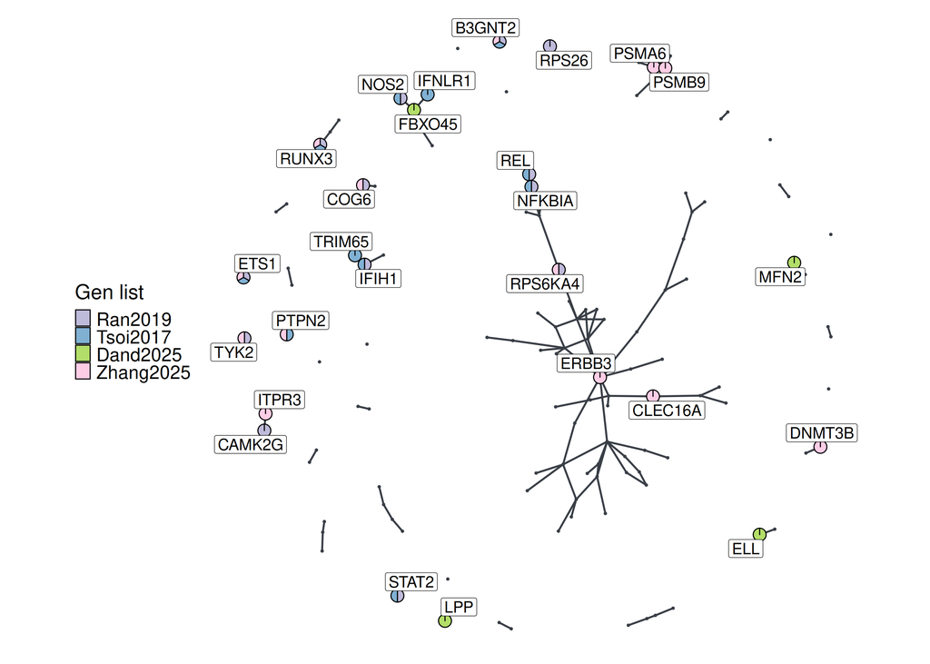

Consensus network comprising 128 genes built by choosing those genes selected in at least 3 methods out of 5. This network highlights genes in common with known gene lists from Ran et al. (2019, Tsoi et al. (2017), Dand et al. (2025) and Zhang et al. (2025).

```r
ran_psoriasis_genes <- read_tsv('data/gene_lists/ran_psoriasis_genes.tsv',
                                col_types = 'cc') %>%
  select(gene) %>%
  mutate(gene = toupper(gene))

tsoi_psoriasis_genes <- read_csv('data/gene_lists/tsoi_psoriasis_genes.csv',
                                 col_types = 'cc') %>%
  select(`Closest Gene`)%>%
  mutate(`Closest Gene` = toupper(`Closest Gene`))

dand_psoriasis_genes <- read_csv('data/gene_lists/dand_psoriasis_closest_protein_genes.tsv',
                                 col_types = 'c') %>%
  select(gene) %>%
  mutate(gene = toupper(gene))

zhang_psoriasis_genes <- read_csv('data/gene_lists/zhang_psoriasis_genes.tsv',
                                  col_types = 'c') %>%
  select(gene) %>%
  mutate(gene = toupper(gene))

gen_list <- c('Ran2019', 'Tsoi2017', 'Dand2025', 'Zhang2025')
gen_list_palette <- c('Ran2019' = '#bebada', 'Tsoi2017' = '#80b1d3', 'Dand2025' = '#b3de69', 'Zhang2025' = '#fccde5')

nodes <- mutate(consensus_gg, Ran2019 = as.numeric(name %in% ran_psoriasis_genes$gene),
                Tsoi2017 =  as.numeric(name %in% tsoi_psoriasis_genes$`Closest Gene`),
                Dand2025 =  as.numeric(name %in% dand_psoriasis_genes$gene),
                Zhang2025 =  as.numeric(name %in% zhang_psoriasis_genes$gene)
                ) %>%
  filter(xend == x & yend == y) %>%
  select(x, y, name, all_of(gen_list)
         ) %>%
  unique

edges <- filter(consensus_gg, xend != x | yend != y)

common_ran_psoriasis_genes <- nodes$name %in% ran_psoriasis_genes$gene
common_tsoi_psoriasis_genes <- nodes$name %in% tsoi_psoriasis_genes$`Closest Gene`
common_dand_psoriasis_genes <- nodes$name %in% dand_psoriasis_genes$gene
common_zhang_psoriasis_genes <- nodes$name %in% zhang_psoriasis_genes$gene
common_all_gen_lists <- common_ran_psoriasis_genes | common_tsoi_psoriasis_genes | common_dand_psoriasis_genes | common_zhang_psoriasis_genes

consensus_pie_gene_lists <- ggplot() +
  geom_edges(data = edges, aes(x = x, y = y, xend = xend, yend = yend),
             color = '#393e46', linewidth = 1) +
  geom_point(data = filter(nodes, !common_all_gen_lists),
             aes(x = x, y = y),
             size = 1, color = '#393e46') +
  geom_scatterpie(data = nodes, aes(x = x, y = y, r=0.011), cols = gen_list) +
  geom_label_repel(data = filter(nodes, common_all_gen_lists),
                   aes(x = x, y = y, label = name),
                   size = 6, point.padding = 1, max.time = 5, max.iter = 20000,
                   max.overlaps = 30) +
  coord_fixed() +
  theme_blank() +
  labs(fill = 'Gen list') +
  scale_fill_manual(values = gen_list_palette) +
  guides(color = "none") +
  theme(legend.position = 'left',
        legend.text = element_text(size = 20, vjust = .2),
        legend.title = element_text(size = 22, vjust = 1)) +
  theme_transparent

consensus_pie_gene_lists
```

## Consensus network (128 genes) — signalling pathways

Same network, highlighting genes in IL-17, IL-23, TNF, IL-1, IFN-γ, IL-22, IL-6, NF-κB, JAK-STAT, MAPK, PI3K-AKT and WNT pathways.

↑ Back to contents

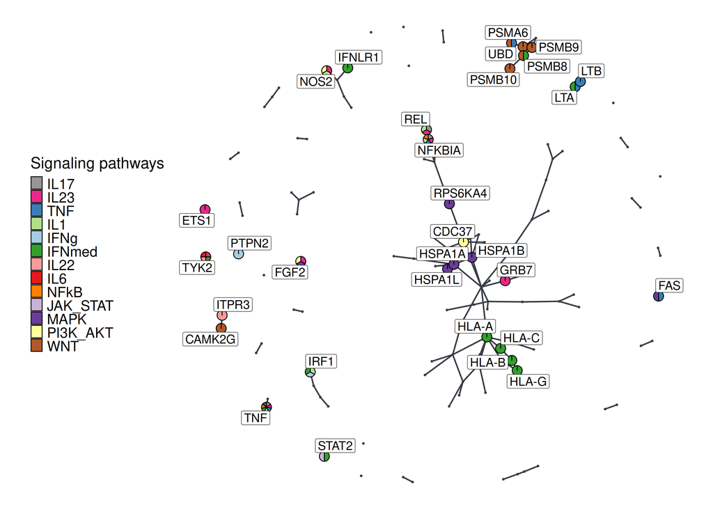

Consensus network comprising 128 genes built by choosing those genes selected in at least 3 methods out of 5. This network highlights genes in common with L-17, IL-23, TNF, IL-1, IFN-γ, IFN -mediated, IL-22, IL-6, NF-κB, JAK-STAT, MAPK, PI3K-AKT and WNT pathways.

```r
il17_signaling_pathway <- read_tsv('data/pathways/il17_signaling_pathway.tsv',
                                   col_types = 'c') %>%
  select(gene) %>%
  mutate(gene = toupper(gene))

il23_signaling_pathway <- read_tsv('data/pathways/il23_signaling_pathway.tsv',
                                   col_types = 'c') %>%
  select(gene) %>%
  mutate(gene = toupper(gene))

tnf_signaling_pathway <- read_tsv('data/pathways/tnf_signaling_pathway.tsv',
                                  col_types = 'c') %>%
  select(gene) %>%
  mutate(gene = toupper(gene))

il1_signaling_pathway <- read_tsv('data/pathways/il1_signaling_pathway.tsv',
                                  col_types = 'c') %>%
  select(gene) %>%
  mutate(gene = toupper(gene))

ifn_gamma_signaling_pathway <- read_tsv('data/pathways/ifn-gamma_signaling_pathway.tsv',
                                        col_types = 'c') %>%
  select(gene) %>%
  mutate(gene = toupper(gene))

interferons_mediated_signaling_pathway <- read_tsv('data/pathways/interferons-mediated_signaling_pathway.tsv',
                                                   col_types = 'c') %>%
  select(gene) %>%
  mutate(gene = toupper(gene))

il22_signaling_pathway <- read_tsv('data/pathways/il22_signaling_pathway.tsv',
                                   col_types = 'c') %>%
  select(gene) %>%
  mutate(gene = toupper(gene))

il6_signaling_pathway <- read_tsv('data/pathways/il6_signaling_pathway.tsv',
                                  col_types = 'c') %>%
  select(gene) %>%
  mutate(gene = toupper(gene))

il9_signaling_pathway <- read_tsv('data/pathways/il9_signaling_pathway.tsv',
                                  col_types = 'c') %>%
  select(gene) %>%
  mutate(gene = toupper(gene))

nfkb_signaling_pathway <- read_tsv('data/pathways/nfkb_signaling_pathway.tsv',
                                   col_types = 'c') %>%
  select(gene) %>%
  mutate(gene = toupper(gene))

jak_stat_signaling_pathway <- read_tsv('data/pathways/jak-stat_signaling_pathway.tsv',
                                       col_types = 'c') %>%
  select(gene) %>%
  mutate(gene = toupper(gene))

mapk_signaling_pathway <- read_tsv('data/pathways/mapk_signaling_pathway.tsv',
                                   col_types = 'c') %>%
  select(gene) %>%
  mutate(gene = toupper(gene))

pi3k_akt_signaling_pathway <- read_tsv('data/pathways/pi3k-akt_signaling_pathway.tsv',
                                       col_types = 'c') %>%
  select(gene) %>%
  mutate(gene = toupper(gene))

wnt_signaling_pathway <- read_tsv('data/pathways/wnt_signaling_pathway.tsv',
                                  col_types = 'c') %>%
  select(gene) %>%
  mutate(gene = toupper(gene))

pathways <- c('IL17','IL23', 'TNF', 'IL1', 'IFNg', 'IFNmed', 'IL22', 'IL6', 'IL9', 'NFkB', 'JAK_STAT', 'MAPK', 'PI3K_AKT', 'WNT')

pathways_palette <- c('IL17' = '#969696', 'IL23' = '#e7298a', 'TNF' = '#377eb8', 'IL1' = '#b2df8a', 'IFNg' = '#a6cee3', 'IFNmed' = '#33a02c', 'IL22' = '#fb9a99', 'IL6' = '#e31a1c', 'IL9' = '#fdbf6f', 'NFkB' = '#ff7f00', 'JAK_STAT' = '#cab2d6', 'MAPK' = '#6a3d9a', 'PI3K_AKT' = '#ffff99', 'WNT' = '#b15928')

nodes <- mutate(consensus_gg, IL17 = as.numeric(name %in% il17_signaling_pathway$gene),
                IL23 = as.numeric(name %in% il23_signaling_pathway$gene),
                TNF =  as.numeric(name %in% tnf_signaling_pathway$gene),
                IL1 =  as.numeric(name %in% il1_signaling_pathway$gene),
                IFNg =  as.numeric(name %in% ifn_gamma_signaling_pathway$gene),
                IFNmed =  as.numeric(name %in% interferons_mediated_signaling_pathway$gene),
                IL22 =  as.numeric(name %in% il22_signaling_pathway$gene),
                IL6 =  as.numeric(name %in% il6_signaling_pathway$gene),
                IL9 =  as.numeric(name %in% il9_signaling_pathway$gene),
                NFkB =  as.numeric(name %in% nfkb_signaling_pathway$gene),
                JAK_STAT =  as.numeric(name %in% jak_stat_signaling_pathway$gene),
                MAPK =  as.numeric(name %in% mapk_signaling_pathway$gene),
                PI3K_AKT =  as.numeric(name %in% pi3k_akt_signaling_pathway$gene),
                WNT =  as.numeric(name %in% wnt_signaling_pathway$gene)
                ) %>%
  filter(xend == x & yend == y) %>%
  select(x, y, name, all_of(pathways)
         ) %>%
  unique

edges <- filter(consensus_gg, xend != x | yend != y)

common_il17_pathway <- nodes$name %in% il17_signaling_pathway$gene
common_il23_pathway <- nodes$name %in% il23_signaling_pathway$gene
common_tnf_pathway <- nodes$name %in% tnf_signaling_pathway$gene
common_il1_pathway <- nodes$name %in% il1_signaling_pathway$gene
common_ifn_gamma_pathway <- nodes$name %in% ifn_gamma_signaling_pathway$gene
common_ifnmed_pathway <- nodes$name %in% interferons_mediated_signaling_pathway$gene
common_il22_pathway <- nodes$name %in% il22_signaling_pathway$gene
common_il6_pathway <- nodes$name %in% il6_signaling_pathway$gene
common_il9_pathway <- nodes$name %in% il9_signaling_pathway$gene
common_nfkb_pathway <- nodes$name %in% nfkb_signaling_pathway$gene
common_jak_stat_pathway <- nodes$name %in% jak_stat_signaling_pathway$gene
common_mapk_pathway <- nodes$name %in% mapk_signaling_pathway$gene
common_pi3k_akt_pathway <- nodes$name %in% pi3k_akt_signaling_pathway$gene
common_wnt_pathway <- nodes$name %in% wnt_signaling_pathway$gene
common_all_pathways <- (common_il17_pathway | common_il23_pathway | common_tnf_pathway |
                        common_il1_pathway | common_ifn_gamma_pathway | common_ifnmed_pathway |
                        common_il22_pathway | common_il6_pathway | common_il9_pathway |
                        common_nfkb_pathway | common_jak_stat_pathway | common_mapk_pathway |
                        common_pi3k_akt_pathway | common_wnt_pathway)

consensus_pie_pathways <- ggplot() +
  geom_edges(data = edges, aes(x = x, y = y, xend = xend, yend = yend),
             color = '#393e46', linewidth = 1) +
  geom_point(data = filter(nodes, !common_all_pathways),
             aes(x = x, y = y),
             size = 1, color = '#393e46') +
  geom_scatterpie(data = nodes, aes(x = x, y = y, r=0.011), cols = pathways) +
  geom_label_repel(data = filter(nodes, common_all_pathways),
                   aes(x = x, y = y, label = name),
                   size = 6, point.padding = 1, max.time = 5, max.iter = 20000,
                   max.overlaps = 50) +
  coord_fixed() +
  theme_blank() +
  labs(fill = 'Signaling pathways') +
  scale_fill_manual(values = pathways_palette) +
  guides(color = "none") +
  theme(legend.position = 'left',
        legend.text = element_text(size = 20, vjust = .2),
        legend.title = element_text(size = 22, vjust = 1)) +
  theme_transparent

consensus_pie_pathways
```